# EPL 2019/2020

## INRTODUCTION

**Overview**

The english premier league 2019/20 season was 29 games in when it was abruptly cut short by the covid-19 pandemic. Although some would say that by this time the tittle holder was already known and that handing over the cup was the only thing left , there was still much to play for.The top 4 spots and relegation battle were really interesting.

We will work with the data that we have and visualize some statistics throughout the season.

**Objectives**

We will answer some few questions like

1. Does home vs away really matter?

**Outcome**

Home advantage is real mainly due to the home crowd.

Basically let us have fun with the data.

**Load in the libraries**

```r
library(tidyverse)
library(corrplot)
```

**Load in the data.**

```r
epl <- read.csv("C:/Users/USER/Desktop/epl/epl2020.csv", stringsAsFactors=FALSE)
str(epl)
```

```
## 'data.frame':    576 obs. of  45 variables:
##  $ X           : int  1 2 3 4 5 6 7 8 9 10 ...
##  $ h_a         : chr  "h" "a" "a" "h" ...
##  $ xG          : num  2.235 0.842 3.184 1.2 1.341 ...
##  $ xGA         : num  0.842 2.235 1.2 3.184 1.599 ...
##  $ npxG        : num  2.235 0.842 2.423 1.2 1.341 ...
##  $ npxGA       : num  0.842 2.235 1.2 2.423 1.599 ...
##  $ deep        : int  11 5 9 1 4 5 0 5 5 6 ...
##  $ deep_allowed: int  5 11 1 9 6 7 9 5 5 4 ...
##  $ scored      : int  4 1 5 0 1 3 3 0 0 1 ...
##  $ missed      : int  1 4 0 5 1 0 0 0 0 1 ...
##  $ xpts        : num  2.386 0.44 2.631 0.252 1.017 ...
##  $ result      : chr  "w" "l" "w" "l" ...
##  $ date        : chr  "2019-08-09 20:00:00" "2019-08-09 20:00:00" "2019-08-10 12:30:00" "2019-08-10 12:30:00" ...
##  $ wins        : int  1 0 1 0 0 1 1 0 0 0 ...
```

[output cut: 31 more lines]

# DATA CLEANING

**We check for missing variables.**

```r
Missing_Indices<-sapply(epl, function(x)sum(is.na(x)))
Missing_Summary<-data.frame(Index=names(epl), Missing_Values=Missing_Indices)
Missing_Summary[Missing_Summary$Missing_Values>0,]
```

| Index | Missing_Values |
| --- | --- |

**There are no missing variables.**

# DATA EXPLORATION.

## WHO WON THE EPL 19/20 SEASON

Let us show the table of the results.

```r
epl.table<-epl %>%
  group_by(teamId) %>%
  summarise(Played=n(),
            Points=sum(pts),
            Goals.For=sum(scored),
            Goals.Against=sum(missed),
            Goal.Difference=(Goals.For -Goals.Against)) %>%
  arrange(desc(Points))

epl.table
```

| teamId | Played | Points | Goals.For | Goals.Against | Goal.Difference |
| --- | --- | --- | --- | --- | --- |
| Liverpool | 29 | 82 | 66 | 21 | 45 |
| Man City | 28 | 57 | 68 | 31 | 37 |
| Leicester | 29 | 53 | 58 | 28 | 30 |
| Chelsea | 29 | 48 | 51 | 39 | 12 |
| Man Utd | 29 | 45 | 44 | 30 | 14 |
| Sheffield United | 28 | 43 | 30 | 25 | 5 |
| Wolves | 29 | 43 | 41 | 34 | 7 |
| Tottenham | 29 | 41 | 47 | 40 | 7 |
| Arsenal | 28 | 40 | 40 | 36 | 4 |
| Burnley | 29 | 39 | 34 | 40 | -6 |

[output cut: 10 more lines]

If the season were to end,

The winners - **Liverpool**

Relegation - **Norwich** , **West Ham** and **Aston Villa**

Let us compare **Liverpool** and **Norwich** seasons.

# LIVERPOOL

Let us take a look at the stats of the premier league holders.

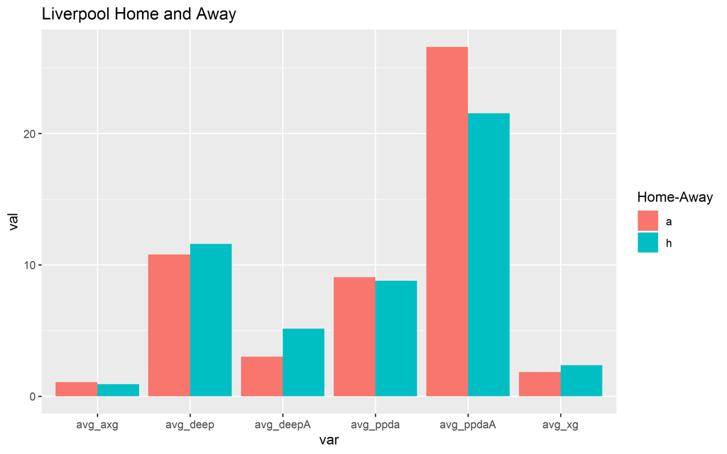

```r
Liverpool<-epl %>%
  filter(teamId=="Liverpool") %>%
  group_by(h_a) %>%
  summarise(played=n(),
            avg_xg=mean(xG),
            avg_axg=mean(xGA),
            tot_scored=sum(scored),
            tot_conceeded=sum(missed),
            avg_ppda=mean(ppda_cal),
            avg_ppdaA=mean(allowed_ppda),
            avg_deep=mean(deep),
            avg_deepA=mean(deep_allowed))

gather_Liverpool<-gather(Liverpool, key="var", value="val", -h_a)


gather_Liverpool[c(3:6, 11:18),] %>%
  ggplot(aes(x=var, y=val, fill=h_a)) +
  geom_col(position = "dodge") +
  labs(title="Liverpool Home and Away",
       fill = "Home-Away")
```

Their average xG is sligher higher at home. When they are away the opposition is expected to score more goals looking at the axG. Funny enough they allow more opponents in their final third when they are home .Average PPDA is lower at home meaning they manage to press their opponents better at home.

# NORWICH

Let us look at the stats of the team bottom of the table.

[figure not shown]

```r
Norwich<-epl %>%
  filter(teamId=="Norwich") %>%
  group_by(h_a) %>%
  summarise(played=n(),
            avg_xg=mean(xG),
            avg_axg=mean(xGA),
            tot_scored=sum(scored),
            tot_conceeded=sum(missed),
            avg_ppda=mean(ppda_cal),
            avg_ppdaA=mean(allowed_ppda),
            avg_deep=mean(deep),
            avg_deepA=mean(deep_allowed))

gather_Norwich<-gather(Norwich, key="var", value="val", -h_a)


gather_Liverpool[c(3:6, 11:18),] %>%
  ggplot(aes(x=var, y=val, fill=h_a)) +
  geom_col(position = "dodge") +
  labs(title="Norwich Home and Away",
       fill="Home-Away")
```

# GOALS

Our favourite part of the game, goals.

We want to find out which factors affect number of goals scored in a game,which team scored the most goals, which half had the most goals scored...

**Correlaion**  
First of all we identify the numeric variables.

```r
numericVars<-which(sapply(epl, is.numeric)) #Index vector for numeric variables.
numericVarsNames<-names(numericVars) #name vectors for numeric variables.
```

Now we find their correlation.

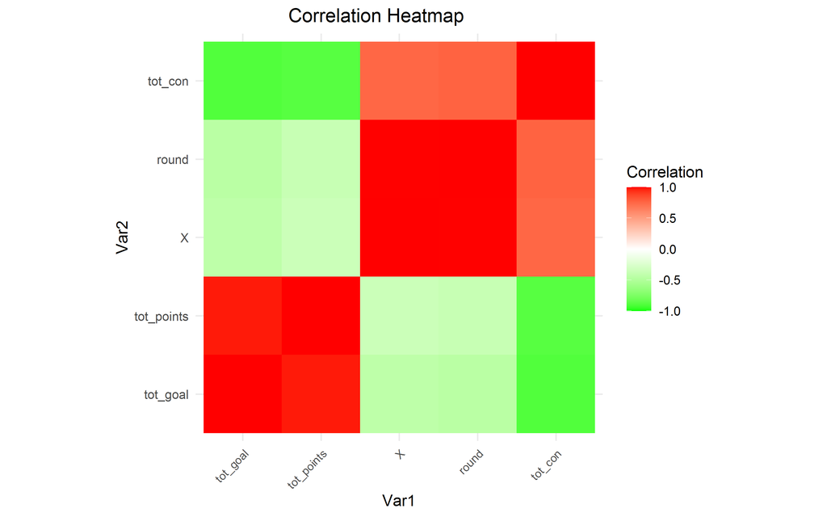

```r
epl_numVar<-epl[,numericVars]
cor_numVar<-cor(epl_numVar, use="pairwise.complete.obs")

#sort on decreasing correlation with goals.
cor_sorted<-as.matrix(sort(cor_numVar[,"tot_goal"],decreasing = TRUE))

#select only high correlations.
corHigh<-names(which(apply(cor_sorted,1 , function(x)abs(x)>0.5)))
cor_numVar<-cor_numVar[corHigh,corHigh]

heat <-epl_numVar

library(reshape2)

qplot(x=Var1, y=Var2, data = melt(cor(cor_numVar, use="p")), fill=value, geom="tile") +
  scale_fill_gradient2(low="green", high="red", mid="white", midpoint=0, limit=c(-1,1), space = "lab", name="Correlation") +
  theme_minimal() +
  theme(axis.text.x = element_text(angle=45, vjust=1, size=8, hjust=1)) +
  coord_fixed() +
  ggtitle("Correlation Heatmap") +
  theme(plot.title = element_text(hjust = 0.4))
```

**Total goals** has a high correlation(0.98) with **Total points** .The more goals you score the higher your chance of winning the match.

**Which team had the most goals**

```r
epl %>%
  group_by(teamId) %>%
  summarise(goals_for=sum(scored),
            goals_against=sum(missed),
            difference=(goals_for - goals_against)) %>%
  arrange(desc(difference))
```

| teamId | goals_for | goals_against | difference |
| --- | --- | --- | --- |
| Liverpool | 66 | 21 | 45 |
| Man City | 68 | 31 | 37 |
| Leicester | 58 | 28 | 30 |
| Man Utd | 44 | 30 | 14 |
| Chelsea | 51 | 39 | 12 |
| Tottenham | 47 | 40 | 7 |
| Wolves | 41 | 34 | 7 |
| Sheffield United | 30 | 25 | 5 |
| Arsenal | 40 | 36 | 4 |
| Burnley | 34 | 40 | -6 |

[output cut: 10 more lines]

**Liverpool** had the **highest goal difference** of **45** while **Norwich** had the lowest of **-27**

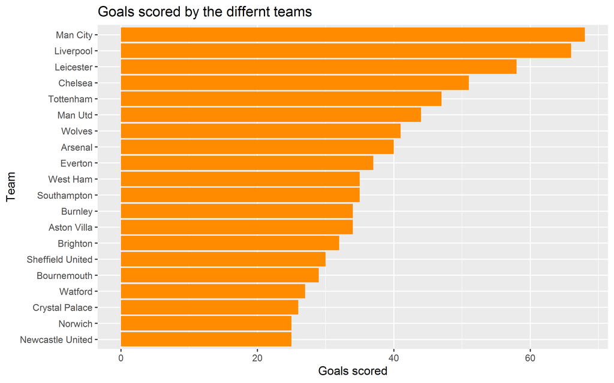

```r
epl.table %>%
  mutate(teamId = fct_reorder(teamId, Goals.For)) %>%
  ggplot(aes(x=Goals.For, y=teamId)) +
  geom_col(fill="darkorange") +
  labs(x="Goals scored",
       y="Team",
       title="Goals scored by the differnt teams")
```

As shown above, the difference between the goals scored by the top and bottom team is large(**over 40 goals**). This can be attributed to quality of players and style of play by different managers.Most teams are around the **30 - 40** mark.

# MATCHDAY

**Does matchday matter?**

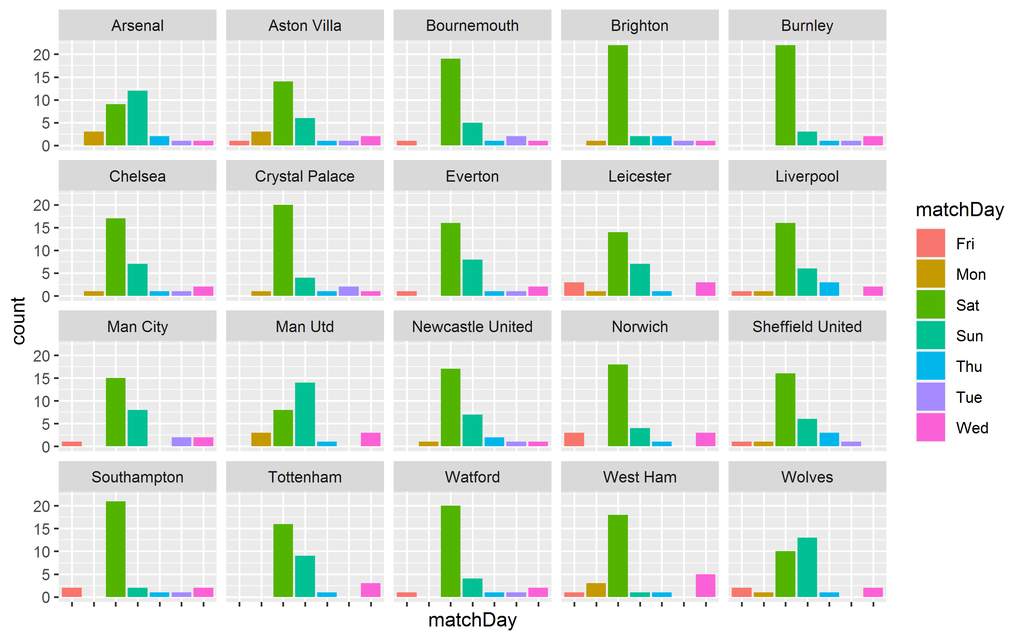

```r
Match_days<-epl %>%
  group_by(teamId ,matchDay) %>%
  summarise(count=n())

Match_days %>%
  ggplot(aes(x=matchDay,y=count,fill=matchDay)) +
  geom_col() +
  facet_wrap(~ teamId) +
  theme(axis.text.x=element_blank())
```

**Arsenal** and **Wolves** had more spread out matchdays thus a hectic schedule but they performed relatively well on the table.

So we can conclude that **Matchday does not matter as much** but there are other external factors that contribute to perfoamnce such as participation in other competitions.

# HOME VS AWAY

**Home table**

```r
h_table<-epl %>%
  filter(h_a =="h") %>%
  group_by(teamId) %>%
  arrange(teamId,date) %>%
  summarise(played=n(),
            h_points=sum(pts),
            h_goals=sum(scored),
            h_con=sum(missed),
            goal_diff=h_goals - h_con,
            success_h=h_points/(played *3)) %>%
  arrange(desc(h_points))

h_table
```

| teamId | played | h_points | h_goals | h_con | goal_diff | success_h |
| --- | --- | --- | --- | --- | --- | --- |
| Liverpool | 15 | 45 | 40 | 12 | 28 | 1.0000000 |
| Leicester | 15 | 30 | 30 | 15 | 15 | 0.6666667 |
| Man City | 13 | 29 | 33 | 12 | 21 | 0.7435897 |
| Man Utd | 15 | 29 | 29 | 12 | 17 | 0.6444444 |
| Arsenal | 15 | 26 | 26 | 20 | 6 | 0.5777778 |
| Tottenham | 14 | 26 | 27 | 15 | 12 | 0.6190476 |
| Everton | 14 | 25 | 19 | 15 | 4 | 0.5952381 |
| Chelsea | 15 | 24 | 22 | 15 | 7 | 0.5333333 |
| Sheffield United | 15 | 24 | 17 | 13 | 4 | 0.5333333 |
| Burnley | 15 | 23 | 20 | 19 | 1 | 0.5111111 |

[output cut: 10 more lines]

**Away table**

```r
a_table<-epl %>%
  filter(h_a=="a") %>%
  group_by(teamId) %>%
  arrange(teamId,date) %>%
  summarise(played=n(),
            a_points=sum(pts),
            a_goals=sum(scored),
            a_con=sum(missed),
            goal_diff=a_goals - a_con,
            success_a=a_points/(played *3)) %>%
  arrange(desc(a_points))

a_table
```

| teamId | played | a_points | a_goals | a_con | goal_diff | success_a |
| --- | --- | --- | --- | --- | --- | --- |
| Liverpool | 14 | 37 | 26 | 9 | 17 | 0.8809524 |
| Man City | 15 | 28 | 35 | 19 | 16 | 0.6222222 |
| Chelsea | 14 | 24 | 29 | 24 | 5 | 0.5714286 |
| Leicester | 14 | 23 | 28 | 13 | 15 | 0.5476190 |
| Wolves | 14 | 21 | 20 | 17 | 3 | 0.5000000 |
| Southampton | 14 | 20 | 19 | 21 | -2 | 0.4761905 |
| Sheffield United | 13 | 19 | 13 | 12 | 1 | 0.4871795 |
| Crystal Palace | 14 | 17 | 14 | 19 | -5 | 0.4047619 |
| Burnley | 14 | 16 | 14 | 21 | -7 | 0.3809524 |
| Man Utd | 14 | 16 | 15 | 18 | -3 | 0.3809524 |

[output cut: 10 more lines]

There are a couple of interesting things.

The last team on the home table has a success rate of **0.31** while the bottom team on the away table has a success rate of **0.13**.

On the **home table** the highetst **goal difference** is **28** while on the away table it is **17**

We can conclude that **home advantage is real** mainly due to the crowd.

# Home vs Away success difference

```r
successDiff<-inner_join(h_table[,c(1,7)], a_table[,c(1,7)]) #joing the home sucess and away colums grouped by team id.

successDiff %>%
  mutate(diff=success_h - success_a) %>%
  arrange(desc(diff))
```

| teamId | success_h | success_a | diff |
| --- | --- | --- | --- |
| Everton | 0.5952381 | 0.2666667 | 0.32857143 |
| Tottenham | 0.6190476 | 0.3333333 | 0.28571429 |
| Man Utd | 0.6444444 | 0.3809524 | 0.26349206 |
| Aston Villa | 0.4358974 | 0.1777778 | 0.25811966 |
| Norwich | 0.3571429 | 0.1333333 | 0.22380952 |
| Arsenal | 0.5777778 | 0.3589744 | 0.21880342 |
| Newcastle United | 0.5000000 | 0.3111111 | 0.18888889 |
| Brighton | 0.4285714 | 0.2444444 | 0.18412698 |
| Bournemouth | 0.4047619 | 0.2222222 | 0.18253968 |
| Watford | 0.4047619 | 0.2222222 | 0.18253968 |

[output cut: 10 more lines]

**Wolves**, **Chelsea** and **Southampton** performed better away compared to home.

**Everton** had the best perfomance difference.

# REFEREES

```r
refs<-epl %>%
  group_by(Referee.x) %>%
  summarise(games=n()/2) %>%
  arrange(desc(games))

refs
```

| Referee.x | games |
| --- | --- |
| M Atkinson | 25 |
| A Taylor | 23 |
| M Oliver | 23 |
| M Dean | 22 |
| C Kavanagh | 20 |
| J Moss | 20 |
| K Friend | 20 |
| P Tierney | 20 |
| A Marriner | 17 |
| C Pawson | 15 |

[output cut: 12 more lines]

M Atkinsonn was the referee in most games(**25**). Some referees like S SCott and T Robinson had only one game each. They were probably junior referees.

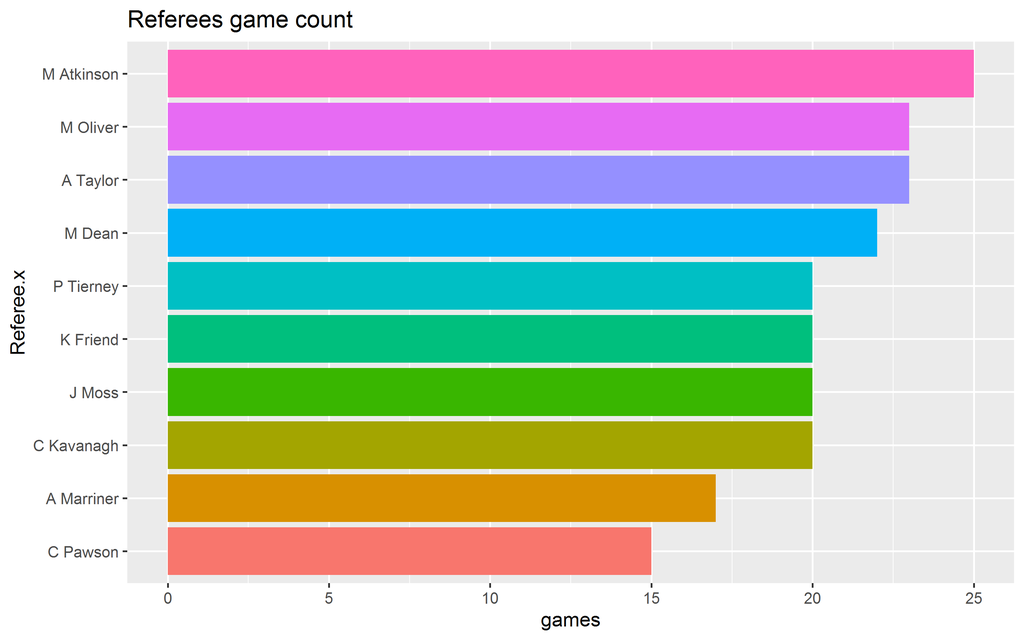

```r
head(refs, 10) %>%
  mutate(Referee.x= fct_reorder(Referee.x, games)) %>%
  ggplot(aes(x=Referee.x, y=games, fill=Referee.x)) +
  geom_col(show.legend = FALSE) +
  coord_flip() +
  labs(title="Referees game count")
```

# M ATKINSON

Let us focus on the referee with the most game count. Which teams did he ref the most.

```r
Atkn<-epl %>%
  filter(Referee.x=="M Atkinson") %>%
  group_by(teamId) %>%
  summarise(games=n()) %>%
  arrange(desc(games))

Atkn
```

| teamId | games |
| --- | --- |
| Arsenal | 5 |
| Newcastle United | 5 |
| Bournemouth | 4 |
| Tottenham | 4 |
| Aston Villa | 3 |
| Brighton | 3 |
| Crystal Palace | 3 |
| Liverpool | 3 |
| Man Utd | 3 |
| Watford | 3 |

[output cut: 9 more lines]

He was the referee most number of times in Arsenal and Newcastle games, **5 each.**

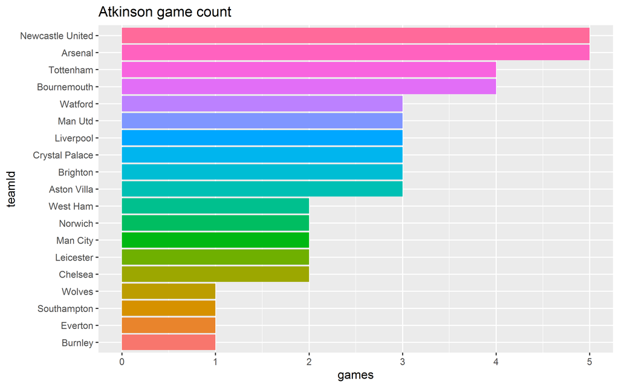

```r
Atkn %>%
  mutate(teamId = fct_reorder(teamId,games)) %>%
  ggplot(aes(x=teamId, y=games, fill=teamId)) +
  geom_col(show.legend = FALSE) +
  coord_flip() +
  labs(title="Atkinson game count")
```

# STRICTNESS OF THE REFEREES

## Yellow cards

```r
yellow_cards<-epl %>%
  group_by(Referee.x) %>%
  summarise(games=n(),
            total_yellow=sum(HY.x,AY.x),
            card_per_game=total_yellow/games) %>%
  arrange(desc(card_per_game))

yellow_cards
```

| Referee.x | games | total_yellow | card_per_game |
| --- | --- | --- | --- |
| P Bankes | 14 | 64 | 4.571429 |
| M Dean | 44 | 200 | 4.545455 |
| S Attwell | 30 | 130 | 4.333333 |
| A Taylor | 46 | 196 | 4.260870 |
| A Madley | 18 | 74 | 4.111111 |
| C Pawson | 30 | 122 | 4.066667 |
| R Jones | 2 | 8 | 4.000000 |
| J Moss | 40 | 152 | 3.800000 |
| L Mason | 26 | 96 | 3.692308 |
| C Kavanagh | 40 | 136 | 3.400000 |

[output cut: 12 more lines]

**P Bankes** gave out the most yellow cards per game, **approximately 5**.

**O Langford** gave out **1** card per game.

Plotting the data.

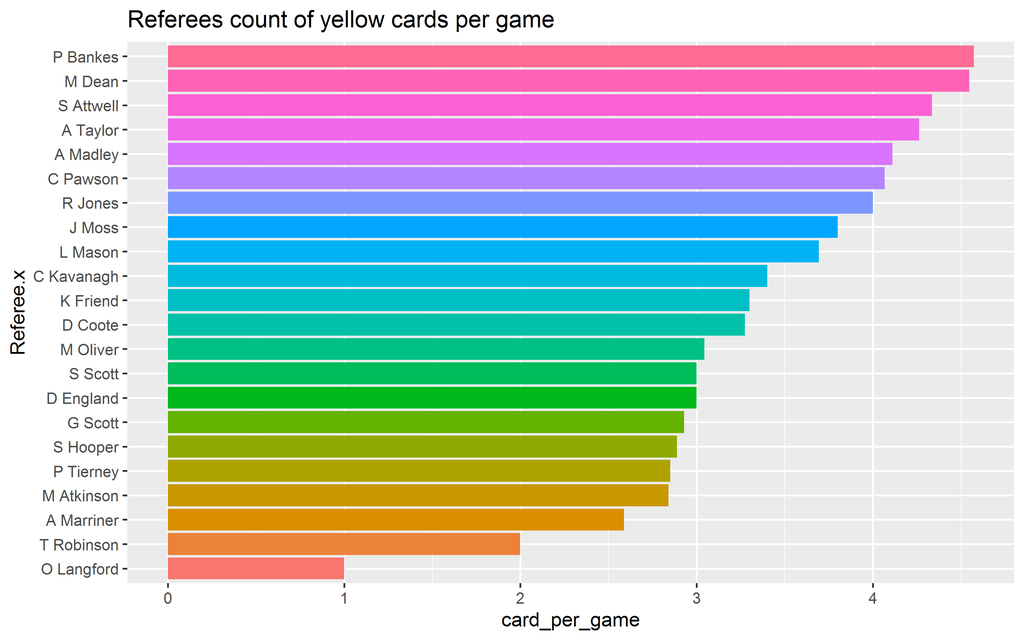

```r
yellow_cards %>%
  mutate(Referee.x = fct_reorder(Referee.x, card_per_game)) %>%
  ggplot(aes(x=card_per_game, y=Referee.x, fill=Referee.x)) +
  geom_col(show.legend = FALSE) +
  labs(title="Referees count of yellow cards per game")
```

## Red cards

```r
red_cards<-epl %>%
  group_by(Referee.x) %>%
  summarise(games=n(),
            total_red=sum(HR.x,AR.x),
            card_per_game=total_red/games) %>%
  arrange(desc(card_per_game))

red_cards
```

| Referee.x | games | total_red | card_per_game |
| --- | --- | --- | --- |
| G Scott | 28 | 8 | 0.28571429 |
| S Hooper | 18 | 4 | 0.22222222 |
| M Dean | 44 | 8 | 0.18181818 |
| A Taylor | 46 | 8 | 0.17391304 |
| K Friend | 40 | 6 | 0.15000000 |
| P Tierney | 40 | 6 | 0.15000000 |
| P Bankes | 14 | 2 | 0.14285714 |
| C Pawson | 30 | 4 | 0.13333333 |
| S Attwell | 30 | 4 | 0.13333333 |
| M Atkinson | 50 | 6 | 0.12000000 |

[output cut: 12 more lines]

Red cards were issued sparingly with the highest **G Scott** with approximately **0.3** per game.

Plotting the data.

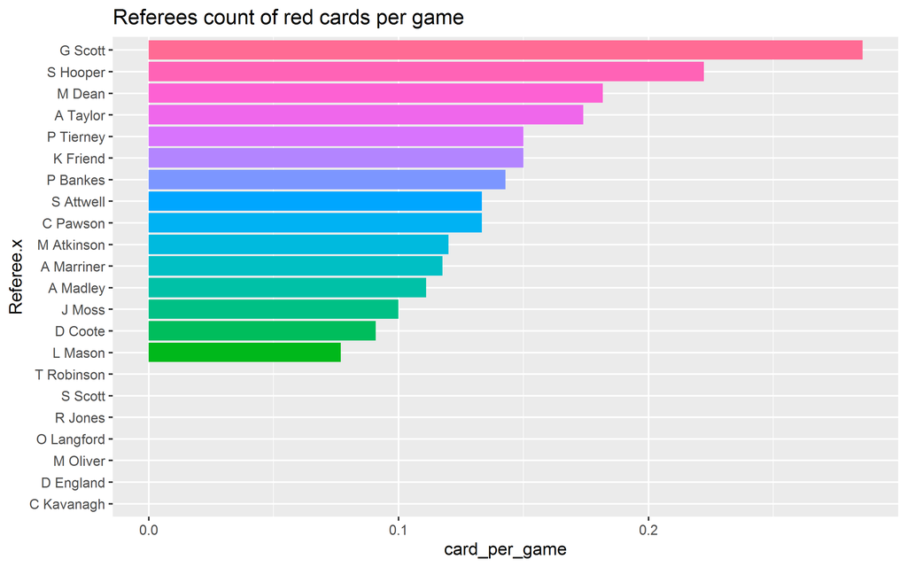

```r
red_cards %>%
  mutate(Referee.x = fct_reorder(Referee.x,card_per_game)) %>%
  ggplot(aes(x=card_per_game, y=Referee.x, fill=Referee.x)) +
  geom_col(show.legend = FALSE) +
  labs(title="Referees count of red cards per game")
```